# Introduction

## Introduction

Comparison of proposed amphibian dermal exposure model (Draft 8/19/15) with collected dermal exposure data. Data is from Van Meter et al. 2014 and Van Meter et al. 2015.

## Computational environment

Location of this repository: https://github.com/puruckertom/amphib_data

Version and installed libraries.

```r
R.Version()$version.string
```

```
## [1] "R version 3.0.3 (2014-03-06)"
```

```r
Sys.info()[4]
```

```
##                    nodename
## "Marcias-MacBook-Pro.local"
```

# Proposed dermal exposure model parameters for amphibians (Document 8/19/15):

## Dermal dose through direct spray-

**Equation 12.** Dermal spray dose = [(Arate * 11.2) (SAtotal * 0.5) * DAF / BW ]* Fred

- Arate = application rate (lb a.i./A)
- 11.2 = conversion from lb a.i./A to ug a.i./g-bw
- SAtotal = Total surface area of organism
- 0.5 = Assumed that either the top half or the bottom half of the animal will be in contact with the ground or direct spray
- DAF = dermal adsorption fraction used to account for pesticide specific data that define a fraction of the pesticide mass present on the animal that is actually absorbed
- BW = body weight
- Fred = Dermal route equivalency factor applied to dermal exposure to derive an estimate of oral dose. Assumed to be 1 for amphibians.
- SAtotal = Surface area total = a3 * BW<sup>b3</sup>
- a3 = 1.131
- b3= 0.579

Same surface area formula used by Van Meter et al.

## Dermal exposure function for dermal spray dose

```r
#convert from g/cm2 to lbs/Acre for input into dermal spray dose function
convert_app_rate<-function(app_rate){
  new_app_rate<-(app_rate * 89217.9122)
  return(new_app_rate)
}
#function to calculate dermal direct spray dose
dermal_spray_dose<-function(Arate, SAtotal, DAF, BW, Fred){
  dsd1<-(((Arate * 11.2) * (SAtotal * 0.5) * DAF / BW )* Fred)
  return (dsd1)
}
#test function returns a value
convert_app_rate(8)
```

```
## [1] 713743.3
```

```r
dermal_spray_dose(7,8,9,10,11)
```

```
## [1] 3104.64
```

## Dermal dose through foliage contact-

**Equation 15.** Dermal contact foliar dose = ( Cplant(t) * Fdfr * Rfoliar contact ^ (8*SAtotal*0.079*0.1) / BW ) * Fred

- Cplant = Concentration of the pesticide in crop foliage at time t. Residue value used for broadleaf foliage concentration in the assessment of dietary exposure
- For broadleaf plants Cplant = 135 * application rate (lbs a.i./hectare)
- Fdfr = Dislodgeable foliar residue adjustment factor
- Rfoliar contact = Rate of foliar contact
- 8 = number of hours per day the animal is active
- SAtotal = surface area total of the organism
- 0.079 = represents the fraction of the animal in contact with the foliage
- 0.1 = unit conversion to ug a.i./g-bw
- BW = body weight of organism
- Fred = Dermal route equivalency factor (1 for amphibians)

Dermal exposure function for indirect dermal dose through foliage contact

```r
# 220462 = unit conversion from g/cm2 to lbs/hectare
# 135 = used in T-Rex to calculate residue on broadleaf plant
# function to calculate Cplant (broadleaf foliar residue from T-Rex)
Cplant_calc<-function(app_rate_g_cm2){
  Cplant_out<-(app_rate_g_cm2 * 220462 * 135)
  return(Cplant_out)
  }
# function to calculate dermal exposure through indirect foliar contact
dermal_contact_dose<-function(Cplant,Fdfr,Rfoliarcontact,SAtotal,BW,Fred){
  dcd1<-( Cplant * Fdfr * Rfoliarcontact ^ (8*SAtotal*0.079*0.1)     / BW ) * Fred
  return (dcd1)
}
#test function returns a value
out1<-Cplant_calc(4)
dermal_contact_dose (out1,2,3,4,5,6)
```

```
## [1] 377185508
```

Use input values from Van Meter et al. database to get estimated dermal spray dose through direct spray and compare with measured body burdens

Use input values from Van Meter et al. database to get estimated dermal spray dose through indirect foliage and compare with measured body burdens

Plots comparing modeled with measured endpoints for direct vs. direct and indirect vs. indirect

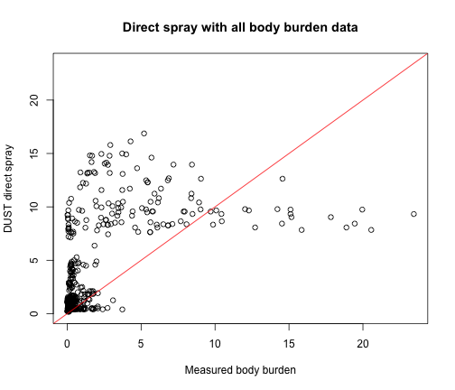

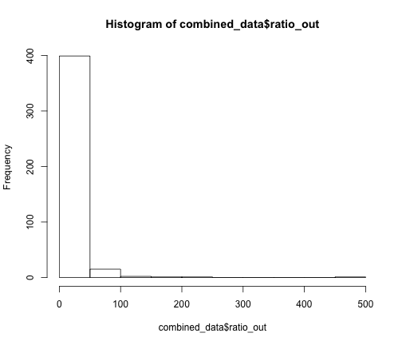

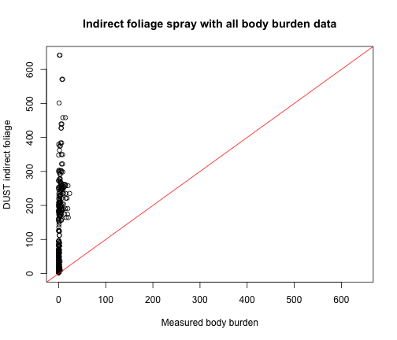

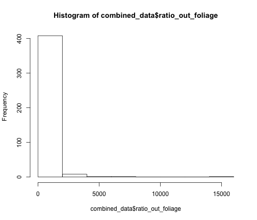

Plots comparing modeled and measured data direct and indirect with total active ingredient data only colored by active ingredient.

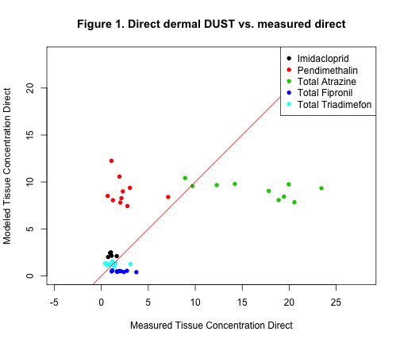

```r
par(mfrow=c(1,1))
# direct dermal DUST vs. measured direct
max1<-max(combined_data2$TissueConc)
min<-0
plot(combined_data2$dermal_spray_dose_out[which(combined_data2$Application=="Direct")]~combined_data2$TissueConc[which(combined_data2$Application=="Direct")], xlab=c('Measured Tissue Concentration Direct'), ylab=c("Modeled Tissue Concentration Direct"),asp=1, pty='s', xlim=c(min,max1), ylim=c(min,max1),pch=16, col=combined_data2$Chemical[which(combined_data2$Application=="Direct")])
abline(0, 1, col="red")
title(main=c("Figure 1. Direct dermal DUST vs. measured direct"))
legend(x="topright", legend = levels(combined_data2$Chemical), col=1:nlevels(combined_data2$Chemical), pch=16)
```

Figure 1 compares DUST model direct spray modelled values with the measured tissue concentration from direct spray of five active ingredients. The model underestimates body burdens for atrazine, triadimefon and fipronil exposures.

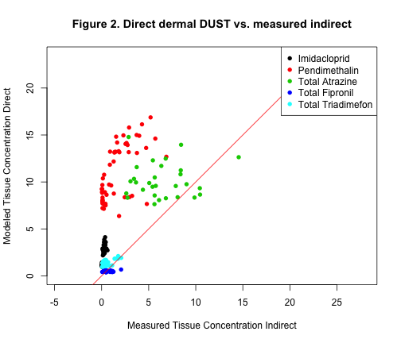

```r
# direct dermal DUST vs. measured indirect
max1<-max(combined_data2$TissueConc)
min<-0
plot(combined_data2$dermal_spray_dose_out[which(combined_data2$Application=="Indirect")]~combined_data2$TissueConc[which(combined_data2$Application=="Indirect")], xlab=c('Measured Tissue Concentration Indirect'), ylab=c("Modeled Tissue Concentration Direct"),asp=1, pty='s', xlim=c(min,max1), ylim=c(min,max1), pch=16,col=combined_data2$Chemical[which(combined_data2$Application=="Indirect")])
abline(0, 1, col="red")
title(main=c("Figure 2. Direct dermal DUST vs. measured indirect"))
legend(x="topright", legend = levels(combined_data2$Chemical), col=1:nlevels(combined_data2$Chemical), pch=16)
```

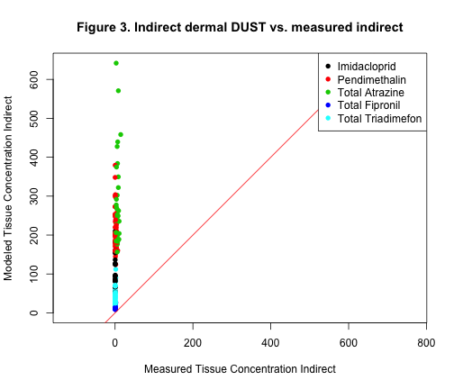

```r
# indirect dermal DUST vs. measured indirect
max1<-max(combined_data2$dermal_foliage_dose_out[which(combined_data2$Application=="Indirect")], na.rm=T)
min<-0
plot(combined_data2$dermal_foliage_dose_out[which(combined_data2$Application=="Indirect")]~combined_data2$TissueConc[which(combined_data2$Application=="Indirect")], xlab=c('Measured Tissue Concentration Indirect'), ylab=c("Modeled Tissue Concentration Indirect"),asp=1, pty='s', xlim=c(min,max1), ylim=c(min,max1), pch=16,col=combined_data2$Chemical[which(combined_data2$Application=="Indirect")])
abline(0, 1, col="red")
title(main=c("Figure 3. Indirect dermal DUST vs. measured indirect"))
legend(x="topright", legend = levels(combined_data2$Chemical), col=1:nlevels(combined_data2$Chemical), pch=16)
```

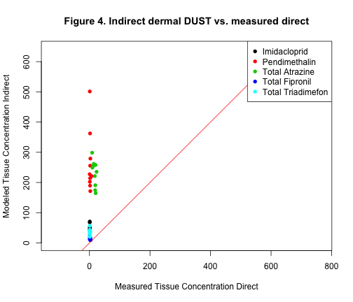

```r
# indirect dermal DUST vs. measured direct
max1<-max(combined_data2$dermal_foliage_dose_out[which(combined_data2$Application=="Indirect")], na.rm=T)
min<-0
plot(combined_data2$dermal_foliage_dose_out[which(combined_data2$Application=="Direct")]~combined_data2$TissueConc[which(combined_data2$Application=="Direct")], xlab=c('Measured Tissue Concentration Direct'), ylab=c("Modeled Tissue Concentration Indirect"),asp=1, pty='s', xlim=c(min,max1), ylim=c(min,max1), pch=16,col=combined_data2$Chemical[which(combined_data2$Application=="Direct")])
abline(0, 1, col="red")
title(main=c("Figure 4. Indirect dermal DUST vs. measured direct"))
legend(x="topright", legend = levels(combined_data2$Chemical), col=1:nlevels(combined_data2$Chemical), pch=16)
```

Figure 4 compares DUST model indirect foliage uptake modelled values with the measured direct uptake for five active ingredients. The modelled values are conservative for all the active ingredients.

# Plots comparing direct DUST vs. indirect DUST model output.

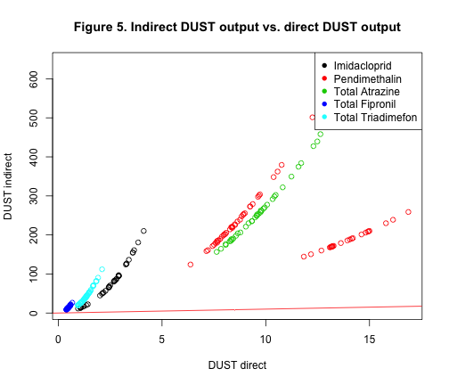

```r
#plot comparing direct vs. indirect DUST model output
plot(combined_data2$dermal_foliage_dose_out~combined_data2$dermal_spray_dose_out, col=combined_data2$Chemical, xlab=c("DUST direct"), ylab=c("DUST indirect"))
legend(x="topright", legend = levels(combined_data2$Chemical), col=1:nlevels(combined_data2$Chemical), pch=16)
title(main=c("Figure 5. Indirect DUST output vs. direct DUST output"))
abline(0,1, col="red")
```

Figure 5. The inputs are the combined data set of application rates and body weights from the amphibians exposed to derive body burdens. Indirect dermal uptake from foliage results are a magnitude of order higher than direct dermal spray uptake.

Plots comparing modeled and measured data direct and indirect with total active ingredient data only colored by species.

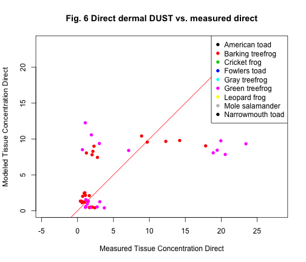

```r
par(mfrow=c(1,1))
# direct dermal DUST vs. measured direct
max1<-max(combined_data2$TissueConc)
min<-0
plot(combined_data2$dermal_spray_dose_out[which(combined_data2$Application=="Direct")]~combined_data2$TissueConc[which(combined_data2$Application=="Direct")], xlab=c('Measured Tissue Concentration Direct'), ylab=c("Modeled Tissue Concentration Direct"),asp=1, pty='s', xlim=c(min,max1), ylim=c(min,max1),pch=16, col=combined_data2$Species[which(combined_data2$Application=="Direct")])
abline(0, 1, col="red")
title(main=c("Fig. 6 Direct dermal DUST vs. measured direct"))
legend(x="topright", legend = levels(combined_data2$Species), col=1:nlevels(combined_data2$Species), pch=16)
```

Fig. 6 Modeled direct overspray of tissue concentration from DUST underestimates measured tissue concentration of some species body burdens when compared to measured direct exposure body burdens.

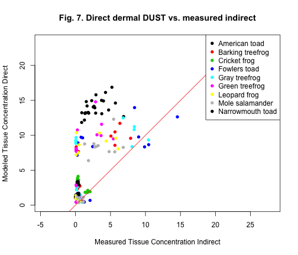

```r
# direct dermal DUST vs. measured indirect
max1<-max(combined_data2$TissueConc)
min<-0
plot(combined_data2$dermal_spray_dose_out[which(combined_data2$Application=="Indirect")]~combined_data2$TissueConc[which(combined_data2$Application=="Indirect")], xlab=c('Measured Tissue Concentration Indirect'), ylab=c("Modeled Tissue Concentration Direct"),asp=1, pty='s', xlim=c(min,max1), ylim=c(min,max1), pch=16,col=combined_data2$Species[which(combined_data2$Application=="Indirect")])
abline(0, 1, col="red")
title(main=c("Fig. 7. Direct dermal DUST vs. measured indirect"))
legend(x="topright", legend = levels(combined_data2$Species), col=1:nlevels(combined_data2$Species), pch=16)
```

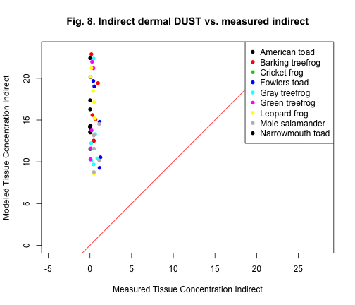

```r
# indirect dermal DUST vs. measured indirect
max1<-max(combined_data2$TissueConc)
min<-0
plot(combined_data2$dermal_foliage_dose_out[which(combined_data2$Application=="Indirect")]~combined_data2$TissueConc[which(combined_data2$Application=="Indirect")], xlab=c('Measured Tissue Concentration Indirect'), ylab=c("Modeled Tissue Concentration Indirect"),asp=1, pty='s', xlim=c(min,max1), ylim=c(min,max1), pch=16,col=combined_data2$Species[which(combined_data2$Application=="Indirect")])
abline(0, 1, col="red")
title(main=c("Fig. 8. Indirect dermal DUST vs. measured indirect"))
legend(x="topright", legend = levels(combined_data2$Species), col=1:nlevels(combined_data2$Species), pch=16)
```

Fig. 8. Modeled indirect overspray of tissue concentration from DUST is conservative of measured tissue concentration of all species body burdens when compared to measured indirect exposure body burdens.

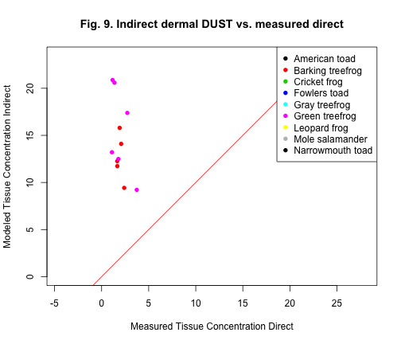

```r
# indirect dermal DUST vs. measured direct
max1<-max(combined_data2$TissueConc[which(combined_data2$Application=="Direct")])
min<-0
plot(combined_data2$dermal_foliage_dose_out[which(combined_data2$Application=="Direct")]~combined_data2$TissueConc[which(combined_data2$Application=="Direct")], xlab=c('Measured Tissue Concentration Direct'), ylab=c("Modeled Tissue Concentration Indirect"),asp=1, pty='s', xlim=c(min,max1), ylim=c(min,max1), pch=16,col=combined_data2$Species[which(combined_data2$Application=="Direct")])
abline(0, 1, col="red")
title(main=c("Fig. 9. Indirect dermal DUST vs. measured direct"))
legend(x="topright", legend = levels(combined_data2$Species), col=1:nlevels(combined_data2$Species), pch=16)
```

Fig 9. Based on data from green treefrog and barking treefrog species the indirect DUST output is conservative of direct overspray measured body burdens.

Plot comparing direct and indirect DUST model output

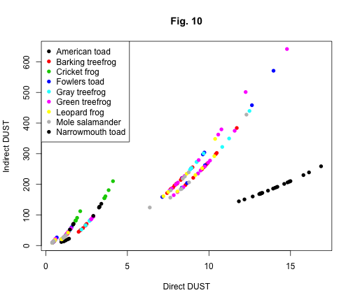

```r
#plot comparing direct vs. indirect DUST model output
plot(combined_data2$dermal_foliage_dose_out~combined_data2$dermal_spray_dose_out, col=combined_data2$Species, pch=16, xlab=c("Direct DUST"), ylab=c("Indirect DUST"))
legend(x="topleft", legend = levels(combined_data2$Species), col=1:nlevels(combined_data2$Species), pch=16)
title(main=c("Fig. 10"))
```

Dust modeled indirect foliage dermal exposure values are an order of magntide greater than dust direct spray dermal exposure values.